# Movie_recommendation_Practice

```python
#下载数据集
#数据集下载
import pandas as pd
from sklearn.model_selection import train_test_split
import numpy as np
from collections import Counter
import tensorflow as tf

import os
import pickle#pickle提供了一个简单的持久化功能。可以将对象以文件的形式存放在磁盘上。
import re
from tensorflow.python.ops import math_ops
```

```python
from urllib.request import urlretrieve
from os.path import isfile,isdir
from tqdm import tqdm#进度条库
import zipfile
import hashlib

def _unzip(save_path,_,database_name,data_path):
    """
    Unzip wrapper with the same interface as _ungzip
    :param save_path: The path of the gzip files
    :param database_name: Name of database
    :param data_path: Path to extract to
    :param _: HACK - Used to have to same interface as _ungzip
    """
    print('Extracting {}...'.format(database_name))
    #ZipFile是zipfile包中的一个类，用来创建和读取zip文件
    with zipfile.ZipFile(save_path) as zf:
        zf.extractall(data_path)

def download_extract(database_name,data_path):
    """
    Download and extract database
    :param database_name:Database name
    """
    DATASET_ML1M = 'ml-1m'
    if database_name == DATASET_ML1M:
        url = 'http://files.grouplens.org/datasets/movielens/ml-1m.zip'
        hash_code = 'c4d9eecfca2ab87c1945afe126590906'
        extract_path = os.path.join(data_path, 'ml-1m')#os.path.join将多个路径组合后返回，提取数据的路径
        save_path = os.path.join(data_path, 'ml-1m.zip')#要保存的路径
        extract_fn = _unzip


    if os.path.exists(extract_path):
        print('Found {} Data'.format(database_name))
        return

    if not os.path.exists(data_path):#指定路径（文件或者目录）不存在，则递归创建目录data_path
        os.makedirs(data_path)


    if not os.path.exists(save_path): #指定路径（文件或者目录）不存在，则递归创建目录save_path
        with DLProgress(unit='B', unit_scale=True, miniters=1, desc='Downloading {}'.format(database_name)) as pbar:
            urlretrieve(
                url,
                save_path,
                pbar.hook)

    assert hashlib.md5(open(save_path, 'rb').read()).hexdigest() == hash_code, \
        '{} file is corrupted.  Remove the file and try again.'.format(save_path)
    os.makedirs(extract_path)
    try:
        extract_fn(save_path, extract_path, database_name, data_path)
    except Exception as err:
        shutil.rmtree(extract_path)  # Remove extraction folder if there is an error
        raise err

    print('Done.')


class DLProgress(tqdm):
    """
    Handle Progress Bar while Downloading
    """
    last_block = 0

    def hook(self,block_num=1,block_size=1,total_size=None):
        """
        A hook function that will be called once on establishment of the network connection and
        once after each block read thereafter.该函数在建立网络连接时调用一次，之后在每个块读取后调用一次.
        :param block_num: A count of blocks transferred so far到目前为止转移的块数
        :param block_size: Block size in bytes块大小（字节）
        :param total_size: The total size of the file. This may be -1 on older FTP servers which do not return
                            a file size in response to a retrieval request.文件的总大小。
                            对于较旧的FTP服务器，这可能为-1，该服务器不响应检索请求而返回文件大小。
        """
        self.total = total_size
        self.update((block_num - self.last_block) * block_size)
        self.last_block = block_num
```

```python
data_dir = './'
download_extract('ml-1m', data_dir)
```

```
Found ml-1m Data
```

数据集分为三个文件：用户数据users.dat，电影数据movies.dat和评分数据ratings.dat。

用户数据 分别有用户ID、性别、年龄、职业ID和邮编等字段。

数据中的格式：UserID::Gender::Age::Occupation::Zip-code

Gender is denoted by a "M" for male and "F" for female Age is chosen from the following ranges:

1: "Under 18" 18: "18-24" 25: "25-34" 35: "35-44" 45: "45-49" 50: "50-55" 56: "56+" Occupation is chosen from the following choices:

0: "other" or not specified 1: "academic/educator" 2: "artist" 3: "clerical/admin" 4: "college/grad student" 5: "customer service" 6: "doctor/health care" 7: "executive/managerial" 8: "farmer" 9: "homemaker" 10: "K-12 student" 11: "lawyer" 12: "programmer" 13: "retired" 14: "sales/marketing" 15: "scientist" 16: "self-employed" 17: "technician/engineer" 18: "tradesman/craftsman" 19: "unemployed" 20: "writer"

```python
users_title = ['UserID','Gender','Age','OccupationID','Zip-code']
users = pd.read_table('./ml-1m/users.dat',sep='::',header=None,names=users_title,engine='python')
users.head()
```

|  | UserID | Gender | Age | OccupationID | Zip-code |
| --- | --- | --- | --- | --- | --- |
| 0 | 1 | F | 1 | 10 | 48067 |
| 1 | 2 | M | 56 | 16 | 70072 |
| 2 | 3 | M | 25 | 15 | 55117 |
| 3 | 4 | M | 45 | 7 | 02460 |
| 4 | 5 | M | 25 | 20 | 55455 |

可以看出UserID、Gender、Age和Occupation都是类别字段，其中邮编字段是我们不使用的。

电影数据 分别有电影ID、电影名和电影风格等字段。

数据中的格式：MovieID::Title::Genres

Titles are identical to titles provided by the IMDB (including year of release) Genres are pipe-separated and are selected from the following genres:

Action Adventure Animation Children's Comedy Crime Documentary Drama Fantasy Film-Noir Horror Musical Mystery Romance Sci-Fi Thriller War Western

```python
movies_title = ['MovieID','Title','Genres']
movies = pd.read_table('./ml-1m/movies.dat',sep='::',header=None,names=movies_title,engine='python')
movies.head()
```

|  | MovieID | Title | Genres |
| --- | --- | --- | --- |
| 0 | 1 | Toy Story (1995) | Animation\|Children's\|Comedy |
| 1 | 2 | Jumanji (1995) | Adventure\|Children's\|Fantasy |
| 2 | 3 | Grumpier Old Men (1995) | Comedy\|Romance |
| 3 | 4 | Waiting to Exhale (1995) | Comedy\|Drama |
| 4 | 5 | Father of the Bride Part II (1995) | Comedy |

MovieID是类别字段，Title是文本字段，Genres也是类别字段

评分数据 分别有用户ID、电影ID、评分和时间戳等字段。

数据中的格式：UserID::MovieID::Rating::Timestamp

```
UserIDs range between 1 and 6040
MovieIDs range between 1 and 3952
Ratings are made on a 5-star scale (whole-star ratings only)
Timestamp is represented in seconds since the epoch as returned by time(2)
Each user has at least 20 ratings
```

```python
ratings_title = ['UserID','MovieID','Rating','timestamps']
ratings = pd.read_table('./ml-1m/ratings.dat',sep='::',header=None,names=ratings_title,engine='python')
ratings.head()
```

|  | UserID | MovieID | Rating | timestamps |
| --- | --- | --- | --- | --- |
| 0 | 1 | 1193 | 5 | 978300760 |
| 1 | 1 | 661 | 3 | 978302109 |
| 2 | 1 | 914 | 3 | 978301968 |
| 3 | 1 | 3408 | 4 | 978300275 |
| 4 | 1 | 2355 | 5 | 978824291 |

评分字段Rating就是我们要学习的targets，时间戳字段我们不使用。

关于数据预处理描述： UserID、Occupation和MovieID不用变 Gender字段需要把‘F’和‘M’转换为0和1 Age字段：要转成7个连续数字0~6 Genres字段：是分类字段，要转成数字，首先将Genres中的类别转换成字符串到数字的字典，然后再 将每个电影的Genres字段转换成数字列表。 Titlle字段：处理方式与Genres字段一样，首先创立文本到数字的字典，然后将Title中的描述转成 数字的列表，另外Title中的年份也需要去掉。 Genres和Title字段需要将长度统一，这样在神经网络中方便处理，空白部分使用‘’对应的数字填充

数据集处理

```python
def load_data():
    """
    Load Dataset from file
    """
    #读取User数据
    users_title = ['UserID','Gender','Age','JobID','Zip-code']
    users = pd.read_table('./ml-1m/users.dat',sep='::',header=None,names=users_title,engine='python')
    #使用正则进行过滤，只使用'UserID','Gender','Age','JobID'几项特征
    users = users.filter(regex='UserID|Gender|Age|JobID')
    users_orig = users.values
    #改变User数据中的性别和年龄
    gender_map = {'F':0,'M':1}
    users['Gender'] = users['Gender'].map(gender_map)

    #enumerate() 函数用于将一个可遍历的数据对象(如列表、元组或字符串)组合为一个索引序列
    #set() 函数创建一个无序不重复元素集
    age_map = {val:ii for ii,val in enumerate(set(users['Age']))}
    users['Age'] = users['Age'].map(age_map)



    #读取Movie数据集
    movies_title = ['MovieID', 'Title', 'Genres']
    movies = pd.read_table('./ml-1m/movies.dat', sep='::', header=None, names=movies_title, engine = 'python')
    movies_orig = movies.values
    #将Title中的年份去掉
    pattern = re.compile(r'^(.*)\((\d+)\)$')

    title_map = {val:pattern.match(val).group(1) for ii,val in enumerate(set(movies['Title']))}
    movies['Title'] = movies['Title'].map(title_map)

    #电影类型转数字字典
    genres_set = set()
    for val in movies['Genres'].str.split('|'):
        genres_set.update(val)

    genres_set.add('<PAD>')
    genres2int = {val:ii for ii, val in enumerate(genres_set)}

    #将电影类型转成等长数字列表，长度是18
    genres_map = {val:[genres2int[row] for row in val.split('|')] for ii,val in enumerate(set(movies['Genres']))}

    for key in genres_map:
        for cnt in range(max(genres2int.values()) - len(genres_map[key])):
            genres_map[key].insert(len(genres_map[key]) + cnt,genres2int['<PAD>'])

    movies['Genres'] = movies['Genres'].map(genres_map)

    #电影Title转数字字典
    title_set = set()
    for val in movies['Title'].str.split():
        title_set.update(val)

    title_set.add('<PAD>')
    title2int = {val:ii for ii, val in enumerate(title_set)}

    #将电影Title转成等长数字列表，长度是15
    title_count = 15
    title_map = {val:[title2int[row] for row in val.split()] for ii,val in enumerate(set(movies['Title']))}

    for key in title_map:
        for cnt in range(title_count - len(title_map[key])):
            title_map[key].insert(len(title_map[key]) + cnt,title2int['<PAD>'])

    movies['Title'] = movies['Title'].map(title_map)

    #读取评分数据集
    ratings_title = ['UserID','MovieID', 'ratings', 'timestamps']
    ratings = pd.read_table('./ml-1m/ratings.dat', sep='::', header=None, names=ratings_title, engine = 'python')
    ratings = ratings.filter(regex='UserID|MovieID|ratings')

    #合并三个表
    data = pd.merge(pd.merge(ratings, users), movies)

    #将数据分成X和y两张表
    target_fields = ['ratings']
    features_pd, targets_pd = data.drop(target_fields, axis=1), data[target_fields]

    features = features_pd.values
    targets_values = targets_pd.values

    return title_count, title_set, genres2int, features, targets_values, ratings, users, movies, data, movies_orig, users_orig
```

加载数据并保存到本地 title_count：Title字段的长度（15） title_set：Title文本的集合 genres2int：电影类型转数字的字典 features：是输入X targets_values：是学习目标y ratings：评分数据集的Pandas对象 users：用户数据集的Pandas对象 movies：电影数据的Pandas对象 data：三个数据集组合在一起的Pandas对象 movies_orig：没有做数据处理的原始电影数据 users_orig：没有做数据处理的原始用户数据

```python
title_count, title_set, genres2int, features, targets_values, ratings, users, movies, data, movies_orig, users_orig = load_data()
```

```python
pickle.dump((title_count, title_set, genres2int, features, targets_values, ratings, users, movies, data, movies_orig, users_orig), open('preprocess.p', 'wb'))
```

```python
users.head()
```

|  | UserID | Gender | Age | JobID |
| --- | --- | --- | --- | --- |
| 0 | 1 | 0 | 0 | 10 |
| 1 | 2 | 1 | 5 | 16 |
| 2 | 3 | 1 | 6 | 15 |
| 3 | 4 | 1 | 2 | 7 |
| 4 | 5 | 1 | 6 | 20 |

```python
movies.head()
```

|  | MovieID | Title | Genres |
| --- | --- | --- | --- |
| 0 | 1 | [171, 1774, 4618, 4618, 4618, 4618, 4618, 4618... | [4, 1, 11, 17, 17, 17, 17, 17, 17, 17, 17, 17,... |
| 1 | 2 | [3291, 4618, 4618, 4618, 4618, 4618, 4618, 461... | [18, 1, 2, 17, 17, 17, 17, 17, 17, 17, 17, 17,... |
| 2 | 3 | [2143, 1208, 2789, 4618, 4618, 4618, 4618, 461... | [11, 7, 17, 17, 17, 17, 17, 17, 17, 17, 17, 17... |
| 3 | 4 | [895, 310, 2683, 4618, 4618, 4618, 4618, 4618,... | [11, 12, 17, 17, 17, 17, 17, 17, 17, 17, 17, 1... |
| 4 | 5 | [728, 5103, 2262, 1433, 877, 2073, 4618, 4618,... | [11, 17, 17, 17, 17, 17, 17, 17, 17, 17, 17, 1... |

```python
movies.values[0]
```

```
array([1,
       list([171, 1774, 4618, 4618, 4618, 4618, 4618, 4618, 4618, 4618, 4618, 4618, 4618, 4618, 4618]),
       list([4, 1, 11, 17, 17, 17, 17, 17, 17, 17, 17, 17, 17, 17, 17, 17, 17, 17])],
      dtype=object)
```

```python
title_count, title_set, genres2int, features, targets_values, ratings, users, movies, data, movies_orig, users_orig = pickle.load(open('preprocess.p', mode='rb'))
```

```python
features[1]
```

```
array([2, 1193, 1, 5, 16,
       list([1706, 2973, 586, 2262, 794, 3226, 4618, 4618, 4618, 4618, 4618, 4618, 4618, 4618, 4618]),
       list([12, 17, 17, 17, 17, 17, 17, 17, 17, 17, 17, 17, 17, 17, 17, 17, 17, 17])],
      dtype=object)
```

模型设计

通过研究数据集中的字段类型，我们发现有一些是类别字段，通常的处理是将这些字段转成one hot编码，但是像UserID、MovieID这样的字段就会变成非常的稀疏，输入的维度急剧膨胀，这是我们不愿意见到的，毕竟我这小笔记本不像大厂动辄能处理数以亿计维度的输入：） 所以在预处理数据时将这些字段转成了数字，我们用这个数字当做嵌入矩阵的索引，在网络的第一层使用了嵌入层，维度是（N，32）和（N，16）。

电影类型的处理要多一步，有时一个电影有多个电影类型，这样从嵌入矩阵索引出来是一个（n，32）的矩阵，因为有多个类型嘛，我们要将这个矩阵求和，变成（1，32）的向量。

电影名的处理比较特殊，没有使用循环神经网络，而是用了文本卷积网络，下文会进行说明。

从嵌入层索引出特征以后，将各特征传入全连接层，将输出再次传入全连接层，最终分别得到（1，200）的用户特征和电影特征两个特征向量。

网络的第一层是词嵌入层，由每一个单词的嵌入向量组成的嵌入矩阵。下一层使用多个不同尺寸（窗口大小）的卷积核在嵌入矩阵上做卷积， 窗口大小指的是每次卷积覆盖几个单词。这里跟对图像做卷积不太一样，图像的卷积通常用2x2、3x3、5x5之类的尺寸，而文本卷积要覆盖整 个单词的嵌入向量，所以尺寸是（单词数，向量维度），比如每次滑动3个，4个或者5个单词。第三层网络是max pooling得到一个长向量，最后使用dropout做正则化，最终得到了电影Title的特征。

```python
#辅助函数
def save_params(params):
    """
    Save parameters to file
    """
    pickle.dump(params,open('params.p','wb'))

def load_params():
    """
    load parameters from file
    """
    return pickle.load(open('params.p',mode = 'rb'))
```

```python
#嵌入矩阵的维度
embed_dim = 32
#用户ID个数
uid_max = max(features.take(0,1)) + 1       #6040
#性别个数
gender_max = max(features.take(2,1)) + 1    #2
#年龄类别个数
gender_max = max(features.take(3,1)) + 1   #7
#职业个数
job_max = max(features.take(4,1)) + 1      #21

#电影ID个数
movie_id_max = max(features.take(1,1)) + 1 # 3952
#电影类型个数
movie_categories_max = max(genres2int.values()) + 1 # 18 + 1 = 19
#电影名单词个数
movie_title_max = len(title_set) # 5216

#对电影类型嵌入向量做加和操作
combiner = "sum"

#电影名长度
sentences_size = title_count # = 15

#文本卷积滑动窗口，分别滑动2, 3, 4, 5个单词
window_sizes = {2, 3, 4, 5}
#文本卷积核数量
filter_num = 8


#电影ID转下标的字典，数据集中电影ID跟下标不一致，比如第5行的数据电影ID不一定是5
movieid2idx = {val[0]:i for i,val in enumerate(movies.values)}
```

```python
#number of epochs
num_epochs = 5
#batch size
batch_size = 256

dropout_keep = 0.5
learning_rate = 0.0001
#show stats for every n number of batches
show_every_n_batches = 20

save_dir = './save'
```

输入：

```
定义输入的占位符
```

```python
def get_input():
    uid = tf.placeholder(tf.int32,[None,1],name="uid")
    movie_id = tf.placeholder(tf.int32,[None,1],name="movie_id")
    movie_categories = tf.placeholder(tf.int32,[None,18],name="movie_categories")
    movie_titles = tf.placeholder(tf.int32,[None,15],name="movie_titles")
    targets = tf.placeholder(tf.int32,[None,1],name="targets")
    LearningRate = tf.placeholder(tf.float32,name="LearningRate")
    dropout_keep_prob = tf.placeholder(tf.float32,name="dropout_keep_prob")
    return uid,movie_id,movie_categories,movie_titles,targets,LearningRate,dropout_keep_prob
```

```python
def get_user_embedding(uid):
    #tf.name_scope可以让变量有相同的命名，只是限于tf.Variable的变量
    with tf.name_scope("user_embedding"):
        uid_embed_matrix = tf.Variable(tf.random_uniform([uid_max,embed_dim],-1,1),name = "uid_embed_matrix")
        uid_embed_layer = tf.nn.embedding_lookup(uid_embed_matrix,uid,name="uid_embed_layer")
    return uid_embed_layer
```

将User的嵌入矩阵一起全连接生成User的特征

```python
def get_user_feature_layer(uid_embed_layer):
    with tf.name_scope("user_fc"):
        #第一层全连接
        uid_fc_layer = tf.layers.dense(uid_embed_layer,embed_dim,name="uid_fc_layer",activation = tf.nn.relu)

        #第二层全连接
        user_combine_layer = tf.contrib.layers.fully_connected(uid_fc_layer,200,tf.tanh) #(?,1,200)

        user_combine_layer_flat = tf.reshape(user_combine_layer,[-1,200])

    return user_combine_layer,user_combine_layer_flat
```

定义Movie ID的嵌入矩阵

```python
def get_movie_id_embed_layer(movie_id):
    with tf.name_scope("movie_embedding"):
        movie_id_embed_matrix = tf.Variable(tf.random_uniform([movie_id_max,embed_dim],-1,1),name="movie_id_embed_matrix")
        movie_id_embed_layer = tf.nn.embedding_lookup(movie_id_embed_matrix,movie_id,name="movie_id_embed_layer")
    return movie_id_embed_layer
```

```python
def get_movie_categories_layers(movie_categories):
    with tf.name_scope("movie_categories_layers"):
        movie_categories_embed_matrix = tf.Variable(tf.random_uniform([movie_categories_max,embed_dim],-1,1),name = "movie_categories_embed_matrix")
        movie_categories_embed_layer = tf.nn.embedding_lookup(movie_categories_embed_matrix,movie_categories,name="movie_categories_embed_layer")
        if combiner == "sum":
            movie_categories_embed_layer = tf.reduce_sum(movie_categories_embed_layer,axis=1,keep_dims=True)

    return movie_categories_embed_layer
```

Movie Title的文本卷积网络实现

```python
def get_movie_cnn_layer(movie_titles):
    #从嵌入矩阵中得到电影名对应的各个单词的嵌入向量
    with tf.name_scope("movie_embedding"):
        movie_title_embed_matrix = tf.Variable(tf.random_uniform([movie_title_max, embed_dim], -1, 1), name = "movie_title_embed_matrix")
        movie_title_embed_layer = tf.nn.embedding_lookup(movie_title_embed_matrix, movie_titles, name = "movie_title_embed_layer")
        #用expand_dims来将维度加1,在最后一维
        movie_title_embed_layer_expand = tf.expand_dims(movie_title_embed_layer, -1)

    #对文本嵌入层使用不同尺寸的卷积核做卷积和最大池化
    pool_layer_lst = []
    for window_size in window_sizes:
        with tf.name_scope("movie_txt_conv_maxpool_{}".format(window_size)):
            filter_weights = tf.Variable(tf.truncated_normal([window_size,embed_dim,1,filter_num],stddev=0.1),name="filter_weights")
            filter_bias = tf.Variable(tf.constant(0.1,shape=[filter_num]),name="filter_bias")

            #卷积参数查看：https://www.cnblogs.com/qggg/p/6832342.html
            conv_layer = tf.nn.conv2d(movie_title_embed_layer_expand,filter_weights,[1,1,1,1],padding="VALID",name="conv_layer")
            #tf.nn.bias_add函数将偏差添加到卷积结果上，rulu将结果中小于0的都置为0
            relu_layer = tf.nn.relu(tf.nn.bias_add(conv_layer,filter_bias),name="relu_layer")

            #选择经过滑动窗口后输出的值里边最大值作为池化窗口
            maxpool_layer = tf.nn.max_pool(relu_layer,[1,sentences_size - window_size + 1,1,1],[1,1,1,1],padding="VALID",name="maxpool_layer")
            pool_layer_lst.append(maxpool_layer)

        #Dropput层
        with tf.name_scope("pool_dropout"):
            pool_layer = tf.concat(pool_layer_lst,3,name="pool_layer")#???
            max_num = len(window_sizes) * filter_num
            pool_layer_flat = tf.reshape(pool_layer,[-1,1,max_num],name="pool_layer_flat")

            dropout_layer = tf.nn.dropout(pool_layer_flat,dropout_keep_prob,name="dropout_layer")
        return pool_layer_flat,dropout_layer
```

将Movie的各个层一起做全连接

```python
def get_movie_feature_layer(movie_id_embed_layer):
    with tf.name_scope("movie_fc"):
        #第一层全连接
        movie_id_fc_layer = tf.layers.dense(movie_id_embed_layer,embed_dim,name="movie_id_fc_layer",activation=tf.nn.relu)

        #第二层全连接
        movie_combine_layer = tf.contrib.layers.fully_connected(movie_id_fc_layer, 200, tf.tanh)  #(?, 1, 200)

        movie_combine_layer_flat = tf.reshape(movie_combine_layer, [-1, 200])

    return movie_combine_layer,movie_combine_layer_flat
```

构建计算图 变量常量等等基本量的操作设置完成，意味着最基本的东西都有了，然后接下来很重要的就是那些量和操作怎么组成更大的集合，怎么运行这个集合这些就是计算图谱Graph和Session的作用：（参见https://blog.csdn.net/xierhacker/article/details/53860379） 一、graph 一个TensorFlow的运算，被表示为一个数据流的图。 一幅图中包含一些操作（Operation）对象，这些对象是计算节点。前面说过的Tensor对象，则是表示在不同的操作（operation）间的数据节点 一旦开始任务，就已经有一个默认的图创建好了。可以通过调用tf.get_default_graph()来访问。添加一个操作到默认的图里面，只需调用一个定义了新操作的函数 另外一种典型用法是要使用到Graph.as_default()的上下文管理器(context manager),它能够在这个上下文里面覆盖默认的图.要在某个graph里面定义量,要在with语句的范围里面定义 二.Session(tf.Session) 运行TensorFLow操作（operations）的类,一个Seesion包含了操作对象执行的环境

```python
tf.reset_default_graph()
train_graph = tf.Graph()
with train_graph.as_default():
    #获取输入占位符
    uid,movie_id,movie_categories,movie_titles,targets,lr,dropout_keep_prob = get_input()
    #获取user的四个嵌入向量
    uid_embed_layer = get_user_embedding(uid)
    #得到用户特征
    user_combine_layer, user_combine_layer_flat = get_user_feature_layer(uid_embed_layer)
    #获取电影ID的嵌入向量
    movie_id_embed_layer = get_movie_id_embed_layer(movie_id)
    #获取电影类型的嵌入向量
    movie_categories_embed_layer = get_movie_categories_layers(movie_categories)
    #获取电影名的特征向量
    pool_layer_flat, dropout_layer = get_movie_cnn_layer(movie_titles)
    #得到电影特征
    movie_combine_layer, movie_combine_layer_flat = get_movie_feature_layer(movie_id_embed_layer)
    #计算评分，要注意两个不同的方案，inference的名字（name值）是不一样的，后面做推荐时要根据name取得tensor

    with tf.name_scope("inference"):
        #将用户特征和电影特征作为输入，经过全连接，输出一个值的方案
#         inference_layer = tf.concat([user_combine_layer_flat, movie_combine_layer_flat], 1)  #(?, 200)
#         inference = tf.layers.dense(inference_layer, 1,
#                                     kernel_initializer=tf.truncated_normal_initializer(stddev=0.01),
#                                     kernel_regularizer=tf.nn.l2_loss, name="inference")
        #简单的将用户特征和电影特征做矩阵乘法得到一个预测评分
#        inference = tf.matmul(user_combine_layer_flat, tf.transpose(movie_combine_layer_flat))
        inference = tf.reduce_sum(user_combine_layer_flat * movie_combine_layer_flat, axis=1)
        inference = tf.expand_dims(inference, axis=1)

    with tf.name_scope("loss"):
        #MES损失，将计算值回归到评分
        cost = tf.losses.mean_squared_error(targets,inference)
        loss = tf.reduce_mean(cost)

    #优化损失
    #train_op = tf.train.AdamOptimizer(lr).minimize(loss)  #cost
    global_step = tf.Variable(0, name="global_step", trainable=False)
    optimizer = tf.train.AdamOptimizer(lr)
    gradients = optimizer.compute_gradients(loss)  #cost
    train_op = optimizer.apply_gradients(gradients,global_step=global_step)
```

取得batch

```python
def get_batch(Xs,ys,batch_size):
    for start in range(0,len(Xs),batch_size):
        end = min(start + batch_size,len(Xs))
        yield Xs[start:end],ys[start:end]
```

训练网络

```python
%matplotlib inline
%config InlineBackend.figure_format = 'retina'
import matplotlib.pyplot as plt
import time
import datetime

losses = {'train':[],'test':[]}

with tf.Session(graph=train_graph) as sess:
    #搜集数据给tensorBoard用
    #Keep track of gradient values and sparsity：跟踪梯度和稀疏度
    grad_summaries = []
    for g,v in gradients:
        if g is not None:
            #tf.summary.histogram('summary_name', tensor)用来显示直方图信息
            grad_hist_summary = tf.summary.histogram("{}/grad/hist".format(v.name.replace(':', '_')), g)
            #tf.summary.scalar(name, tensor, collections=None) 用来显示标量信息，一般在画loss,accuary时会用到这个函数
            #tf.nn.zero_fraction统计某个值的0的比例，这个tf.nn.zero_fraction计算出来的值越大，0的比例越高，稀疏度
            sparsity_summary = tf.summary.scalar("{}/grad/sparsity".format(v.name.replace(':', '_')), tf.nn.zero_fraction(g))
            grad_summaries.append(grad_hist_summary)
            grad_summaries.append(sparsity_summary)
    #tf.summary.merge(inputs, collections=None, name=None)将上面几种类型的汇总再进行一次合并，具体合并哪些由inputs指定
    # merge_all将之前定义的所有summary整合在一起
    #和TensorFlow中的其他操作类似，tf.summary.scalar、tf.summary.histogram、tf.summary.image函数也是一个op
    #在定义的时候，也不会立即执行，需要通过sess.run来明确调用这些函数。因为，在一个程序中定义的写日志操作比较多
    #如果一一调用，将会十分麻烦，所以Tensorflow提供了tf.summary.merge_all()函数将所有的summary整理在一起
    #在TensorFlow程序执行的时候，只需要运行这一个操作就可以将代码中定义的所有【写日志操作】执行一次，从而将所有的日志写入【日志文件】。
    grad_summaries_merged = tf.summary.merge(grad_summaries)


    #Output directory for models and summaries
    timestamp = str(int(time.time()))
    out_dir = os.path.abspath(os.path.join(os.path.curdir, "runs", timestamp))
    print("Writing to {}\n".format(out_dir))

    #Summaries for loss and accuracy
    loss_summary = tf.summary.scalar("loss",loss)

    #Train Summaries
    train_summary_op = tf.summary.merge([loss_summary,grad_summaries_merged])
    train_summary_dir = os.path.join(out_dir,"summaries","train")
    train_summary_writer = tf.summary.FileWriter(train_summary_dir, sess.graph)

    # Inference summaries
    inference_summary_op = tf.summary.merge([loss_summary])
    inference_summary_dir = os.path.join(out_dir, "summaries", "inference")
    inference_summary_writer = tf.summary.FileWriter(inference_summary_dir, sess.graph)

    sess.run(tf.global_variables_initializer())
    saver = tf.train.Saver()
    for epoch_i in range(num_epochs):
        #将数据集分成训练集和测试集，随机种子不固定
        train_X,test_X,train_y,test_y = train_test_split(features,
                                                         targets_values,
                                                         test_size = 0.2,
                                                         random_state = 0)

        train_batches = get_batch(train_X,train_y,batch_size)
        test_batches = get_batch(text_X,text_y,batch_size)

        #训练的迭代，保存训练损失
        for batch_i in range(len(train_X) // batch_size):
            x,y = next(train_batches)

            categories = np.zeros([batch_size,18])
            for i in range(batch_size):
                categories[i] = x.take(6,1)[i]

            titles = np.zeros([batch_size, sentences_size])
            for i in range(batch_size):
                titles[i] = x.take(5,1)[i]

            feed = {
                uid:np.reshape(x.take(0,1),[batch_size,1]),
                movie_id:np.reshape(x.take(1,1),[batch_size,1]),
                movie_categories:categories,
                movie_titles:titles,
                targets:np.reshape(y,[batch_size,1]),
                dropout_keep_prob: dropout_keep, #dropout_keep
                lr:learning_rate}

            step,train_loss,summaries,_ = sess.run([global_step,loss,train_summary_op,train_op],feed)
            losses['train'].append(train_loss)
            train_summary_writer.add_summary(summaries, step)  #

            # Show every <show_every_n_batches> batches
            if (epoch_i * (len(train_X) // batch_size) + batch_i) % show_every_n_batches == 0:
                time_str = datetime.datetime.now().isoformat()
                print('{}: Epoch {:>3} Batch {:>4}/{}   train_loss = {:.3f}'.format(
                        time_str,
                        epoch_i,
                        batch_i,
                        (len(train_X) // batch_size),
                        train_loss))

        #使用测试数据的迭代
        for batch_i in range(len(text_X) // batch_size):
            x, y = next(test_batches)

            categories = np.zeros([batch_size, 18])
            for i in range(batch_size):
                categories[i] = x.take(6,1)[i]

            titles = np.zeros([batch_size, sentences_size])
            for i in range(batch_size):
                titles[i] = x.take(5,1)[i]

            feed = {
                uid: np.reshape(x.take(0,1), [batch_size, 1]),
                movie_id: np.reshape(x.take(1,1), [batch_size, 1]),
                movie_categories: categories,  #x.take(6,1)
                movie_titles: titles,  #x.take(5,1)
                targets: np.reshape(y, [batch_size, 1]),
                dropout_keep_prob: 1,
                lr: learning_rate}

            step, test_loss, summaries = sess.run([global_step, loss, inference_summary_op], feed)  #cost


            #保存测试损失
            losses['test'].append(test_loss)
            inference_summary_writer.add_summary(summaries,step)

            time_str = datetime.datetime.now().isoformat()
            if (epoch_i * (len(test_X) // batch_size) + batch_i) % show_every_n_batches == 0:
                print('{}:Epoch {:>3} Batch {:>4}/{}  test_loss = {:.3f}'.format(
                time_str,
                epoch_i,
                batch_i,
                (len(test_X) // batch_size),
                test_loss))

    #save model
    saver.save(sess,save_dir)
    print('Model Trained and Saved')
```

```
Writing to /home/hanxiaoyang/recommender_system/Student/student_472812/runs/1545113983

2018-12-18T14:19:45.864802: Epoch   0 Batch    0/3125   train_loss = 12.903
2018-12-18T14:19:46.171631: Epoch   0 Batch   20/3125   train_loss = 9.588
2018-12-18T14:19:46.508696: Epoch   0 Batch   40/3125   train_loss = 6.188
2018-12-18T14:19:46.864889: Epoch   0 Batch   60/3125   train_loss = 4.305
2018-12-18T14:19:47.189942: Epoch   0 Batch   80/3125   train_loss = 3.565
2018-12-18T14:19:47.514225: Epoch   0 Batch  100/3125   train_loss = 3.131
2018-12-18T14:19:47.821186: Epoch   0 Batch  120/3125   train_loss = 2.795
2018-12-18T14:19:48.135370: Epoch   0 Batch  140/3125   train_loss = 2.428
2018-12-18T14:19:48.447731: Epoch   0 Batch  160/3125   train_loss = 2.375
2018-12-18T14:19:48.775672: Epoch   0 Batch  180/3125   train_loss = 2.687
2018-12-18T14:19:49.058603: Epoch   0 Batch  200/3125   train_loss = 2.855
2018-12-18T14:19:49.357516: Epoch   0 Batch  220/3125   train_loss = 2.060
2018-12-18T14:19:49.650042: Epoch   0 Batch  240/3125   train_loss = 2.495
2018-12-18T14:19:49.947476: Epoch   0 Batch  260/3125   train_loss = 2.388
2018-12-18T14:19:50.250574: Epoch   0 Batch  280/3125   train_loss = 2.137
2018-12-18T14:19:50.567383: Epoch   0 Batch  300/3125   train_loss = 1.965
2018-12-18T14:19:50.881030: Epoch   0 Batch  320/3125   train_loss = 2.193
2018-12-18T14:19:51.190647: Epoch   0 Batch  340/3125   train_loss = 1.873
2018-12-18T14:19:51.491166: Epoch   0 Batch  360/3125   train_loss = 2.127
2018-12-18T14:19:51.800593: Epoch   0 Batch  380/3125   train_loss = 1.890
2018-12-18T14:19:52.114620: Epoch   0 Batch  400/3125   train_loss = 1.935
2018-12-18T14:19:52.450850: Epoch   0 Batch  420/3125   train_loss = 1.650
2018-12-18T14:19:52.751914: Epoch   0 Batch  440/3125   train_loss = 1.884
2018-12-18T14:19:53.059416: Epoch   0 Batch  460/3125   train_loss = 1.543
2018-12-18T14:19:53.366517: Epoch   0 Batch  480/3125   train_loss = 1.972
2018-12-18T14:19:53.665860: Epoch   0 Batch  500/3125   train_loss = 1.298
2018-12-18T14:19:53.976052: Epoch   0 Batch  520/3125   train_loss = 1.804
2018-12-18T14:19:54.267907: Epoch   0 Batch  540/3125   train_loss = 1.666
2018-12-18T14:19:54.561746: Epoch   0 Batch  560/3125   train_loss = 2.049
2018-12-18T14:19:54.868314: Epoch   0 Batch  580/3125   train_loss = 1.892
2018-12-18T14:19:55.176400: Epoch   0 Batch  600/3125   train_loss = 1.897
2018-12-18T14:19:55.492067: Epoch   0 Batch  620/3125   train_loss = 1.938
2018-12-18T14:19:55.833077: Epoch   0 Batch  640/3125   train_loss = 1.735
2018-12-18T14:19:56.146452: Epoch   0 Batch  660/3125   train_loss = 1.816
2018-12-18T14:19:56.464893: Epoch   0 Batch  680/3125   train_loss = 1.830
2018-12-18T14:19:56.783493: Epoch   0 Batch  700/3125   train_loss = 1.553
2018-12-18T14:19:57.105142: Epoch   0 Batch  720/3125   train_loss = 1.511
2018-12-18T14:19:57.419904: Epoch   0 Batch  740/3125   train_loss = 1.555
```

[output cut: 926 more lines]

```
2018-12-18T14:24:21.000625:Epoch   4 Batch  516/781  test_loss = 0.785
2018-12-18T14:24:21.154085:Epoch   4 Batch  536/781  test_loss = 0.916
2018-12-18T14:24:21.328229:Epoch   4 Batch  556/781  test_loss = 0.803
2018-12-18T14:24:21.497339:Epoch   4 Batch  576/781  test_loss = 0.954
2018-12-18T14:24:21.664090:Epoch   4 Batch  596/781  test_loss = 0.959
2018-12-18T14:24:21.812783:Epoch   4 Batch  616/781  test_loss = 0.939
2018-12-18T14:24:21.978692:Epoch   4 Batch  636/781  test_loss = 0.843
2018-12-18T14:24:22.143985:Epoch   4 Batch  656/781  test_loss = 0.917
2018-12-18T14:24:22.323307:Epoch   4 Batch  676/781  test_loss = 1.021
2018-12-18T14:24:22.479798:Epoch   4 Batch  696/781  test_loss = 0.829
2018-12-18T14:24:22.675407:Epoch   4 Batch  716/781  test_loss = 0.829
2018-12-18T14:24:22.849873:Epoch   4 Batch  736/781  test_loss = 1.072
2018-12-18T14:24:23.029090:Epoch   4 Batch  756/781  test_loss = 0.869
2018-12-18T14:24:23.209152:Epoch   4 Batch  776/781  test_loss = 0.767
Model Trained and Saved
```

```python
#保存参数
#保存save_dir在生成预测时使用
save_params((save_dir))

load_dir = load_params()
```

显示训练loss

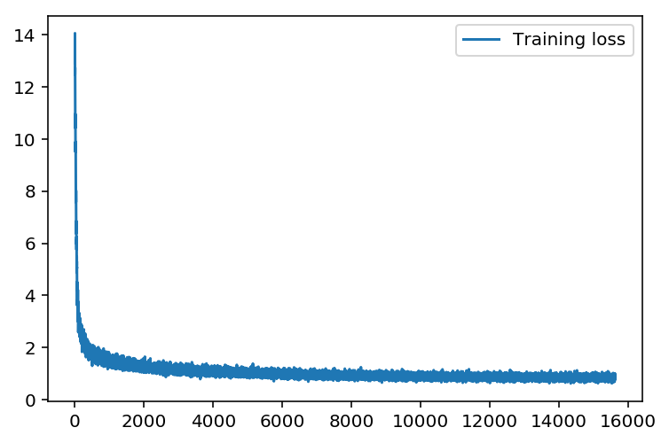

```python
plt.plot(losses['train'],label='Training loss')
plt.legend()
_ = plt.ylim()
```

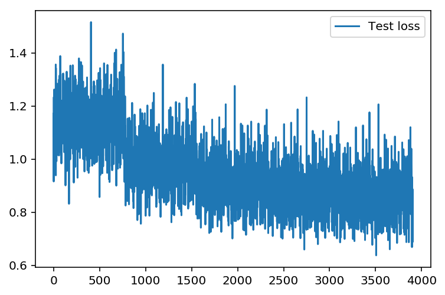

```python
plt.plot(losses['test'],label='Test loss')
plt.legend()
_ = plt.ylim()
```

获取Tensors 使用函数get_tensor_by_name()从loaded_graph中获取tensors,后面的推荐功能要用到

```python
def get_tensors(loaded_graph):

    uid = loaded_graph.get_tensor_by_name("uid:0")
    movie_id = loaded_graph.get_tensor_by_name("movie_id:0")
    movie_categories = loaded_graph.get_tensor_by_name("movie_categories:0")
    movie_titles = loaded_graph.get_tensor_by_name("movie_titles:0")
    targets = loaded_graph.get_tensor_by_name("targets:0")
    dropout_keep_prob = loaded_graph.get_tensor_by_name("dropout_keep_prob:0")
    lr = loaded_graph.get_tensor_by_name("LearningRate:0")

    #两种不同计算预测评分的方案使用不同的name获取tensor inference
    #inference = loaded_graph.get_tensor_by_name("inference/inference/BiasAdd:0")
    inference = loaded_graph.get_tensor_by_name("inference/ExpandDims:0") # 之前是MatMul:0 因为inference代码修改了
    movie_combine_layer_flat = loaded_graph.get_tensor_by_name("movie_fc/Reshape:0")
    user_combine_layer_flat = loaded_graph.get_tensor_by_name("user_fc/Reshape:0")
    return uid, movie_id, movie_categories, movie_titles, targets, lr, dropout_keep_prob, inference, movie_combine_layer_flat, user_combine_layer_flat
```

指定用户和电影进行评分 这部分就是对网络做正向传播，计算得到预测的评分

```python
def rating_movie(user_id_val,movie_id_val):
    loaded_graph = tf.Graph()
    with tf.Session(graph=loaded_graph) as sess:
        #load save model
        loader = tf.train.import_meta_graph(load_dir + '.meta')
        loader.restore(sess,load_dir)

        #get Tensors from loaded model
        uid, movie_id, movie_categories, movie_titles, targets, lr, dropout_keep_prob, inference,_, __ = get_tensors(loaded_graph)  #loaded_graph


        categories = np.zeros([1,18])
        categories[0] = movies.values[movieid2idx[movie_id_val]][2]

        titles = np.zeros([1, sentences_size])
        titles[0] = movies.values[movieid2idx[movie_id_val]][1]

        feed = {
            uid: np.reshape(users.values[user_id_val-1][0], [1, 1]),
            movie_id: np.reshape(movies.values[movieid2idx[movie_id_val]][0], [1, 1]),
            movie_categories: categories,  #x.take(6,1)
            movie_titles: titles,  #x.take(5,1)
            dropout_keep_prob: 1}

        #get prediction
        inference_val = sess.run([inference],feed)

        return inference_val
```

```python
#预测评分
rating_movie(231,1401)
```

```
INFO:tensorflow:Restoring parameters from ./save
```

```
[array([[3.809629]], dtype=float32)]
```

生成Movie特征矩阵，将训练好的电影特征组合成电影特征矩阵并保存到本地

```python
loaded_graph = tf.Graph()
movie_matrixs = []
with tf.Session(graph=loaded_graph) as sess:
    #load save model
    loader = tf.train.import_meta_graph(load_dir + '.meta')
    loader.restore(sess,load_dir)

    #get Tensors from loaded model
    uid, movie_id, movie_categories, movie_titles, targets, lr, dropout_keep_prob, _,movie_combine_layer_flat, __ = get_tensors(loaded_graph)  #loaded_graph

    for item in movies.values:
        categories = np.zeros([1, 18])
        categories[0] = item.take(2)

        titles = np.zeros([1, sentences_size])
        titles[0] = item.take(1)

        feed = {
            movie_id: np.reshape(item.take(0), [1, 1]),
            movie_categories:categories,
            movie_titles:titles,
            dropout_keep_prob: 1}

        movie_combine_layer_flat_val = sess.run([movie_combine_layer_flat],feed)
        movie_matrixs.append(movie_combine_layer_flat_val)


pickle.dump((np.array(movie_matrixs).reshape(-1, 200)), open('movie_matrixs.p', 'wb'))
movie_matrixs = pickle.load(open('movie_matrixs.p', mode='rb'))
```

```
INFO:tensorflow:Restoring parameters from ./save
```

```python
movie_matrixs = pickle.load(open('movie_matrixs.p', mode='rb'))
```

生成User特征矩阵 将训练好的用户特征组合成用户特征矩阵并保存到本地

```python
loaded_graph = tf.Graph()
users_matrixs = []
with tf.Session(graph=loaded_graph) as sess:
    #load save model
    loader = tf.train.import_meta_graph(load_dir + '.meta')
    loader.restore(sess,load_dir)

    uid, movie_id, movie_categories, movie_titles, targets, lr, dropout_keep_prob, _, __ ,user_combine_layer_flat= get_tensors(loaded_graph)  #loaded_graph

    for item in users.values:

        feed = {
            uid: np.reshape(item.take(0), [1, 1]),
            dropout_keep_prob: 1}
        user_combine_layer_flat_val = sess.run([user_combine_layer_flat], feed)
        users_matrixs.append(user_combine_layer_flat_val)

pickle.dump((np.array(users_matrixs).reshape(-1, 200)), open('users_matrixs.p', 'wb'))
users_matrixs = pickle.load(open('users_matrixs.p', mode='rb'))
```

```
INFO:tensorflow:Restoring parameters from ./save
```

```python
users_matrixs = pickle.load(open('users_matrixs.p', mode='rb'))
```

开始推荐电影: 使用生产的用户特征矩阵和电影特征矩阵做电影推荐

推荐同类型的电影: 思路是计算当前看的电影特征向量与整个电影特征矩阵的余弦相似度，取相似度最大的top_k个，这里加了 些随机选择在里面，保证每次的推荐稍稍有些不同。

```python
def recommend_same_type_movie(movie_id_val,top_k=20):

    loaded_graph = tf.Graph()
    with tf.Session(graph=loaded_graph) as sess:
        # Load saved model
        loader = tf.train.import_meta_graph(load_dir + '.meta')
        loader.restore(sess, load_dir)

        #tf.square:每个元素求平方；tf.reduce_sum：后边参数为1，表示按列求和
        norm_movie_matrixs = tf.sqrt(tf.reduce_sum(tf.square(movie_matrixs),1,keep_dims=True))
        normalized_movie_matrixs = movie_matrixs / norm_movie_matrixs


        #推荐同类型电影
        probs_embeddings = (movie_matrixs[movieid2idx[movie_id_val]]).reshape([1,200])
        #tf.transpose:转置
        probs_similarity = tf.matmul(probs_embeddings,tf.transpose(normalized_movie_matrixs))

        sim = (probs_similarity.eval())

        print("您看的电影是：{}". format(movies_orig[movieid2idx[movie_id_val]]))
        print("以下是给你的推荐：")


        #从数组的形状中删除单维条目，即把shape中为1的维度去掉;argsort()将x中的元素从小到大排列，
        p=np.squeeze(sim)
        p[np.argsort(p)[:-top_k]] = 0
        p = p / np.sum(p)
        results = set()
        while len(results) != 5:
            #以p的概率分布从3883个当中选一个
            c = np.random.choice(3883,1,p=p)[0]
            results.add(c)
        for val in results:
            print(val)
            print(movies_orig[val])
        return results
```

```python
recommend_same_type_movie(1401,20)
```

```
INFO:tensorflow:Restoring parameters from ./save
您看的电影是：[1401 'Ghosts of Mississippi (1996)' 'Drama']
以下是给你的推荐：
1065
[1081 'Victor/Victoria (1982)' 'Comedy|Musical']
1506
[1545 'Ponette (1996)' 'Drama']
1844
[1913 'Picnic at Hanging Rock (1975)' 'Drama|Mystery']
310
[313 'Swan Princess, The (1994)' "Animation|Children's"]
2215
[2284 'Bandit Queen (1994)' 'Drama']
```

```
{310, 1065, 1506, 1844, 2215}
```

推荐您喜欢的电影 思路是使用用户特征向量与电影特征矩阵计算所有电影的评分，取评分最高的top_k个，同样加了些随机选择部分。

```python
def recommend_your_favorite_movie(user_id_val,top_k =10):

    loaded_graph = tf.Graph()
    with tf.Session(graph=loaded_graph) as sess:
        # Load saved model
        loader = tf.train.import_meta_graph(load_dir + '.meta')
        loader.restore(sess, load_dir)

        #推荐您喜欢的电影
        probs_embeddings = (users_matrixs[user_id_val - 1]).reshape([1,200])

        probs_similarity = tf.matmul(probs_embeddings,tf.transpose(movie_matrixs))
        sim = (probs_similarity.eval())

        print("以下是给您的推荐：")
        #从数组的形状中删除单维条目，即把shape中为1的维度去掉;argsort()将x中的元素从小到大排列
        p = np.squeeze(sim)
        p[np.argsort(p)[:-top_k]] = 0
        p = p / np.sum(p)
        results = set()
        while len(results) != 5:
            #则以p的概率分布从3883个当中选一个
            c = np.random.choice(3883,1,p=p)[0]
            results.add(c)
        for val in results:
            print(val)
            print(movies_orig[val])

        return results
```

```python
recommend_your_favorite_movie(234,10)
```

```
INFO:tensorflow:Restoring parameters from ./save
以下是给您的推荐：
49
[50 'Usual Suspects, The (1995)' 'Crime|Thriller']
1162
[1178 'Paths of Glory (1957)' 'Drama|War']
3491
[3560 'Phantom Love (Ai No Borei) (1978)' 'Drama']
141
[143 'Gospa (1995)' 'Drama']
911
[923 'Citizen Kane (1941)' 'Drama']
```

```
{49, 141, 911, 1162, 3491}
```

看过这个电影的人还看了（喜欢）哪些电影

1、首先选出喜欢某个电影的top_k个人，得到这几个人的用户特征向量； 2、然后计算这几个人对所有电影的评分； 3、选择每个人评分最高的电影作为推荐； 4、同样加入了随机选择。

```python
import random
def recommend_other_favorite_movie(movie_id_val,top_k=20):
    loaded_graph = tf.Graph()
    with tf.Session(graph=loaded_graph) as sess:
        # Load saved model
        loader = tf.train.import_meta_graph(load_dir + '.meta')
        loader.restore(sess, load_dir)


        probs_movie_embeddings = (movie_matrixs[movieid2idx[movie_id_val]]).reshape([1,200])
        probs_user_favorite_similarity = tf.matmul(probs_movie_embeddings,tf.transpose(users_matrixs))

        #获取喜欢某电影的top_k个人
        favorite_user_id = np.argsort(probs_user_favorite_similarity.eval())[0][-top_k:]

        print("您看的电影是：{}".format(movies_orig[movieid2idx[movie_id_val]]))

        print("喜欢看这个电影的人是：{}".format(users_orig[favorite_user_id-1]))
        probs_users_embeddings = (users_matrixs[favorite_user_id-1]).reshape([-1,200])
        probs_similarity = tf.matmul(probs_users_embeddings,tf.transpose(movie_matrixs))
        sim = (probs_similarity.eval())

        p = np.argmax(sim,1)
        print("喜欢看这个电影的人还喜欢看：")

        results = set()
        while len(results)!=5:
            #randrange() 方法返回指定递增基数集合中的一个随机数，基数缺省值为1。
            c=p[random.randrange(top_k)]
            results.add(c)

        for val in results:
            print(val)
            print(movies_orig[val])

        return results
```

```python
recommend_other_favorite_movie(1401, 20)
```

[output not shown]